# Drzewa klasyfikacyjne

Michał Żychowski

2023-05-26

## Przygotowanie danych

Zaczynajmy od importu naszej bazy danych oraz niezbędnych bibliotek.

```r
library(readxl)
dane <- read_excel("../data/dane.xlsx")
library(MASS)
library(maptree)
library(rpart)
library(rpart.plot)
library(party)
library(class)
```

Generujemy ramkę danych a następnie usuwamy braki danych

```r
dane_pierwotne <- data.frame(dane)
Dane <- na.omit(data.frame(dane_pierwotne))
head(Dane)
```

```
##      Wiek Dochód Stan.cywilny Poziom.wykształcenia Prawo.jazdy
## 1   Młody Wysoki      Singiel               Wysoki         Nie
## 2   Młody Średni      Singiel               Wysoki         Tak
## 3   Młody Średni      Singiel               Średni         Tak
## 4   Młody Średni       Żonaty               Średni         Nie
## 5 Starszy Wysoki       Żonaty                Niski         Nie
## 6 Starszy Średni       Żonaty                Niski         Tak
```

## Tworzenie zbioru uczącego oraz testowego

Przy tworzeniu naszych zbiorów uczących, losowo wybieramy rekordy z naszej ramki danych i przypisujemy je do odpowiednich zbiorów.

```r
Indeksy <- sample(1:nrow(dane),nrow(dane)/2,replace = FALSE)

zbior_uczacy = dane[Indeksy, ]
zbior_testowy = dane[-Indeksy, ]

head(zbior_uczacy)
```

```
## # A tibble: 6 × 5
##   Wiek    Dochód `Stan cywilny` `Poziom wykształcenia` `Prawo jazdy`
##   <chr>   <chr>  <chr>          <chr>                  <chr>
## 1 Młody   Średni Żonaty         Średni                 Tak
## 2 Młody   Niski  Żonaty         Wysoki                 Nie
## 3 Starszy Niski  Żonaty         Wysoki                 Nie
## 4 Młody   Niski  Singiel        Wysoki                 Nie
## 5 Młody   Średni Singiel        Niski                  Nie
## 6 Młody   Wysoki Żonaty         Średni                 Nie
```

```r
head(zbior_testowy)
```

```
## # A tibble: 6 × 5
##   Wiek    Dochód `Stan cywilny` `Poziom wykształcenia` `Prawo jazdy`
##   <chr>   <chr>  <chr>          <chr>                  <chr>
## 1 Młody   Wysoki Singiel        Wysoki                 Nie
## 2 Młody   Średni Singiel        Średni                 Tak
## 3 Młody   Średni Żonaty         Średni                 Nie
## 4 Starszy Średni Żonaty         Niski                  Tak
## 5 Starszy Niski  Żonaty         Średni                 Nie
## 6 Średni  Niski  Żonaty         Wysoki                 Tak
```

## Tworzymy model drzewa

Tworzymy go za pomocą funkcji rpart, wykorzystując zbiór uczący. Ponieważ nasze zmienne są jakościowe, wybieramy metodę “class”.

```r
Drzewo <- rpart(zbior_uczacy$`Prawo jazdy`~.,zbior_uczacy,method = "class")
```

Dla naszego drzewa możemy sprawdzić parametry oraz liczbę gałęzi.

```r
Drzewo$parms
```

```
## $prior
##    1    2
## 0.48 0.52
##
## $loss
##      [,1] [,2]
## [1,]    0    1
## [2,]    1    0
##
## $split
## [1] 1
```

```r
Drzewo$numresp
```

```
## [1] 4
```

W przypadku gdy wygenerowane drzewo jest bardzo rozległe, możemy spróbować je przyciąć. Choć w naszym przypadku liczba gałęzi jest dość mała, warto sprawdzić, czy przycięcie drzewa nie spowoduje poprawy jego jakości.

```r
Model.optimal<-which.min(Drzewo$cptable[,4])
CP.optimal<-Drzewo$cptable[Model.optimal,1]
Drzewo2<-prune(Drzewo,cp=Model.optimal)
```

## Weryfikacja naszych modeli

Teraz, gdy mamy już nasze modele, możemy sprawdzić ich dopasowanie do zbioru uczącego dla naszego pierwotnego drzewa.

```r
prediction1<-predict(Drzewo,zbior_uczacy,type = "class")

print("Tabela dobroci klasyfikacji")
table(predykacja=prediction1,prawdziwe=zbior_uczacy$`Prawo jazdy`)

print("Obliczanie błędu predykcji")
error1<-mean(prediction1 != zbior_uczacy$`Prawo jazdy`)
error1
```

```
## [1] "Tabela dobroci klasyfikacji"
##           prawdziwe
## predykacja Nie Tak
##        Nie  14   9
##        Tak  10  17
## [1] "Obliczanie błędu predykcji"
## [1] 0.38
```

oraz dla przyciętego drzewa

```r
prediction2<-predict(Drzewo2,zbior_uczacy,type = "class")

print("Tabela dobroci klasyfikacji")
table(predykacja=prediction2,prawdziwe=zbior_uczacy$`Prawo jazdy`)

print("Obliczanie błędu predykcji")
error2<-mean(prediction2 != zbior_uczacy$`Prawo jazdy`)
error2
```

```
## [1] "Tabela dobroci klasyfikacji"
##           prawdziwe
## predykacja Nie Tak
##        Nie   0   0
##        Tak  24  26
## [1] "Obliczanie błędu predykcji"
## [1] 0.48
```

Zauważamy, że nasze przycięte drzewo ma większy błąd predykcji. Niemniej jednak, nie powinniśmy go jeszcze odrzucać, ponieważ istnieje możliwość, że będzie on miało znacznie mniejszy błąd predykcji na zbiorze testowym.

## Testowanie na zbiorze testowym

```r
TPrediction1<-predict(Drzewo,zbior_testowy,type = "class")
errorT1<-mean(TPrediction1 != zbior_testowy$`Prawo jazdy`)
print("Błąd predykcji drzewa")
errorT1

TPrediction2<-predict(Drzewo2,zbior_testowy,type = "class")
errorT2<-mean(TPrediction2 != zbior_testowy$`Prawo jazdy`)
print("Błąd predykcji drzewa Przyciętego")
errorT2
```

```
## [1] "Błąd predykcji drzewa"
## [1] 0.44
## [1] "Błąd predykcji drzewa Przyciętego"
## [1] 0.62
```

Teraz możemy ocenić, który model powinniśmy wybrać. Jednak należy pamiętać, że podział na zbiór uczący i testowy jest losowy, więc przy kolejnym uruchomieniu kodu możemy uzyskać inny wynik.

## Rysowanie drzewa

Po dokonaniu wyboru, który model jest lepszy, możemy go przedstawić w postaci wykresu, aby lepiej zobrazować jego działanie.

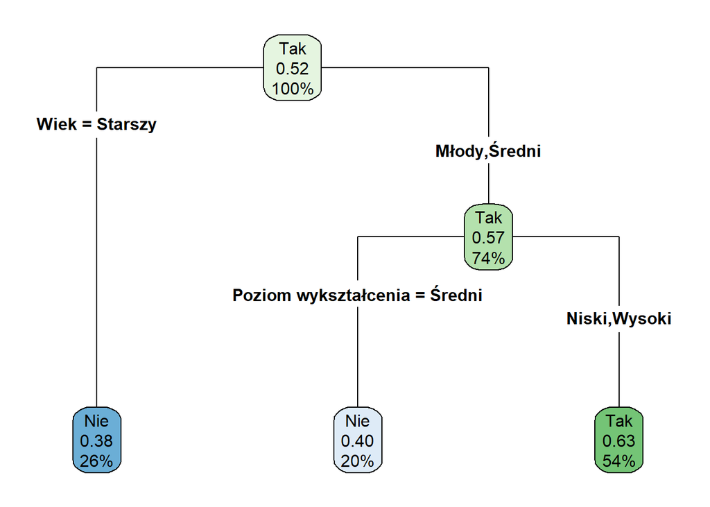

```r
rpart.plot(Drzewo,type = 4,extra="auto")
```

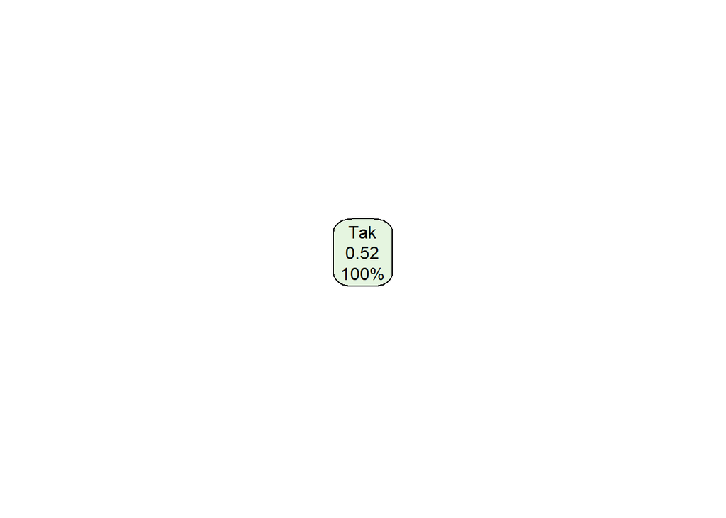

```r
rpart.plot(Drzewo2,type = 4,extra="auto")
```